# HW12_syQiu

Author

Shuyi Qiu

Set-up

```r
library(tidyverse)
library(ggplot2)
library(gssr)
library(bayesrules)
library(broom)
gss18 <- gss_get_yr(2018)
theme_set(theme_light(base_family = "Optima"))
```

# 12.1.4 Normal() Part1

Set $\mu=0$

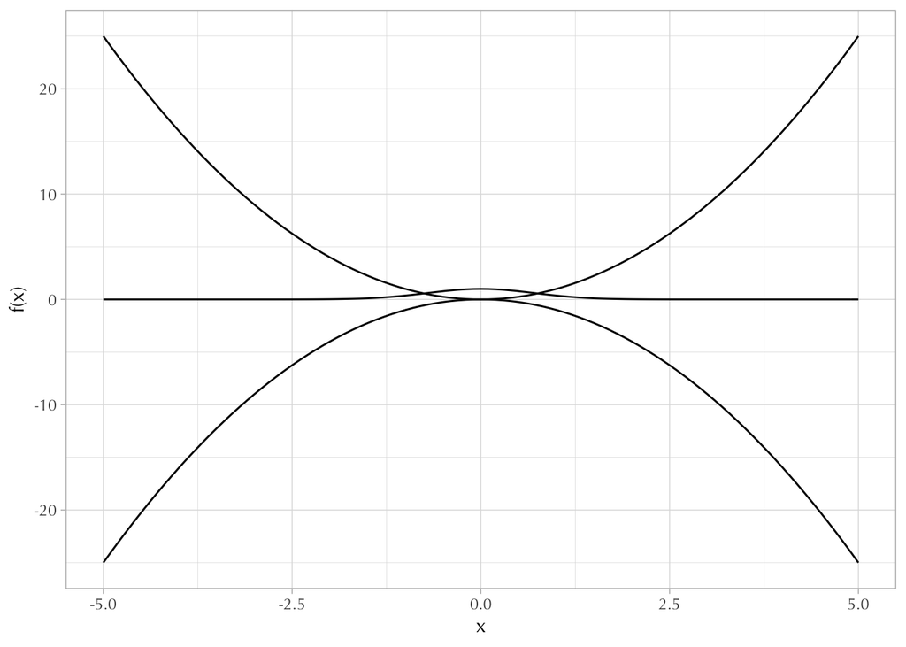

```r
mu = 0
ggplot() +
  xlim(-5, 5) +
  geom_function(fun = \(x) (x - mu)^2) +
  geom_function(fun = \(x) -(x-mu)^2) +
  geom_function(fun = \(x) exp(-(x-mu)^2)) +
  labs(x = "x", y = "f(x)")
```

Unlike $x^2$ and $-x^2$, the area under $e^{-x^2}$ is limited.

# 12.1.5 Normal() Part2

```r
sqrt(pi) # Square root of pi
```

```
[1] 1.772454
```

```r
integrate(f = \(x) 1/sqrt(pi) * exp(-x^2), lower = -Inf, upper = Inf) # The area under the curve
```

```
1 with absolute error < 2.4e-06
```

We can see that $\sqrt{\pi}$ equals to the integral of $e^{-x^2}$. Therefore, the denominator $\sqrt{\pi}$ is to standardize the function to a distribution which the area under the curve is 1.

Similarly, the density function of normal distribution can be explained as:

$$f(x)=\frac{1}{\sqrt{\pi2\sigma^2}}exp(-\frac{(x-\mu)^2}{2\sigma^2})$$

- $\mu$ is the center of the distribution.
- the denominator in the power number of exponential $2\sigma^2$ is the spread of the curve. The denominator in the total function $\sqrt{\pi2\sigma^2}$ is to adjust the area under the curve to be 1, so that it satisfy the basic condition of a probability distribution

# 12.1.7 Height ~ Sex + Age

Import GSS dataset

$$height = \alpha + \beta*male$$

```r
df <- gss18 |>
  select(height, sex, age) |>
  haven::zap_missing() |>
  mutate(
    sex_new = factor(ifelse(sex == 1, "male", "female"))
  ) |>
  drop_na()

mod1 <- lm(formula = height ~ sex_new, data = df)
summary(mod1)
```

```
Call:
lm(formula = height ~ sex_new, data = df)

Residuals:
     Min       1Q   Median       3Q      Max
-16.4099  -2.1149  -0.1149   1.8851  10.8851

Coefficients:
            Estimate Std. Error t value Pr(>|t|)
(Intercept)  64.4099     0.1115  577.54   <2e-16 ***
sex_newmale   5.7050     0.1610   35.43   <2e-16 ***
---
Signif. codes:  0 '***' 0.001 '**' 0.01 '*' 0.05 '.' 0.1 ' ' 1

Residual standard error: 3.007 on 1395 degrees of freedom
Multiple R-squared:  0.4736,    Adjusted R-squared:  0.4732
F-statistic:  1255 on 1 and 1395 DF,  p-value: < 2.2e-16
```

$\alpha$: The average height of female is 64.41 inches.

$\beta$: The average height of male is 70.11 inches.

Now we add age as a second predictor

$$height = \alpha + \beta_1*male + \beta_2*age$$

```r
mod2 <- lm(formula = height ~ sex_new + age, data = df)
summary(mod2)
```

```
Call:
lm(formula = height ~ sex_new + age, data = df)

Residuals:
     Min       1Q   Median       3Q      Max
-16.4202  -2.0971  -0.1285   1.8852  10.9193

Coefficients:
             Estimate Std. Error t value Pr(>|t|)
(Intercept) 64.469454   0.270356 238.462   <2e-16 ***
sex_newmale  5.705584   0.161111  35.414   <2e-16 ***
age         -0.001368   0.005657  -0.242    0.809
---
Signif. codes:  0 '***' 0.001 '**' 0.01 '*' 0.05 '.' 0.1 ' ' 1

Residual standard error: 3.008 on 1394 degrees of freedom
Multiple R-squared:  0.4736,    Adjusted R-squared:  0.4729
F-statistic: 627.1 on 2 and 1394 DF,  p-value: < 2.2e-16
```

$\alpha$: The intercept is the average height of female who was at the age of 0, which is impossible. Therefore we do not interpret this.

$\beta_1$: The average height of male is higher than female by 5.71 inches.

$\beta_2$: For every additional year of age, the height will be lower by -0.001 inches.

# 12.1.8 Inc ~ Age

$$coninc_i=\beta_0 + \beta_1age_i + \beta_2age_i^2$$

```r
df <- gss18 |>
  select(coninc, age) |>
  mutate(
    age_sq = age^2
  ) |>
  drop_na()

mod3 <- lm(formula = coninc ~ age + age_sq, data = df)
summary(mod3)
```

```
Call:
lm(formula = coninc ~ age + age_sq, data = df)

Residuals:
   Min     1Q Median     3Q    Max
-58467 -29026 -10827  16788 131721

Coefficients:
              Estimate Std. Error t value Pr(>|t|)
(Intercept) -15627.326   6832.034  -2.287   0.0223 *
age           2820.031    286.520   9.842   <2e-16 ***
age_sq         -26.706      2.765  -9.659   <2e-16 ***
---
Signif. codes:  0 '***' 0.001 '**' 0.01 '*' 0.05 '.' 0.1 ' ' 1

Residual standard error: 41520 on 2144 degrees of freedom
Multiple R-squared:  0.04324,   Adjusted R-squared:  0.04235
F-statistic: 48.45 on 2 and 2144 DF,  p-value: < 2.2e-16
```

$\beta_0$ here is the average inflation-adjusted family income when the respondent is at the age of 0. However this does not make much sense to measure the income at the age of 0, so it does not have actual interpretation here.

Predict for the age from 18 to 85:

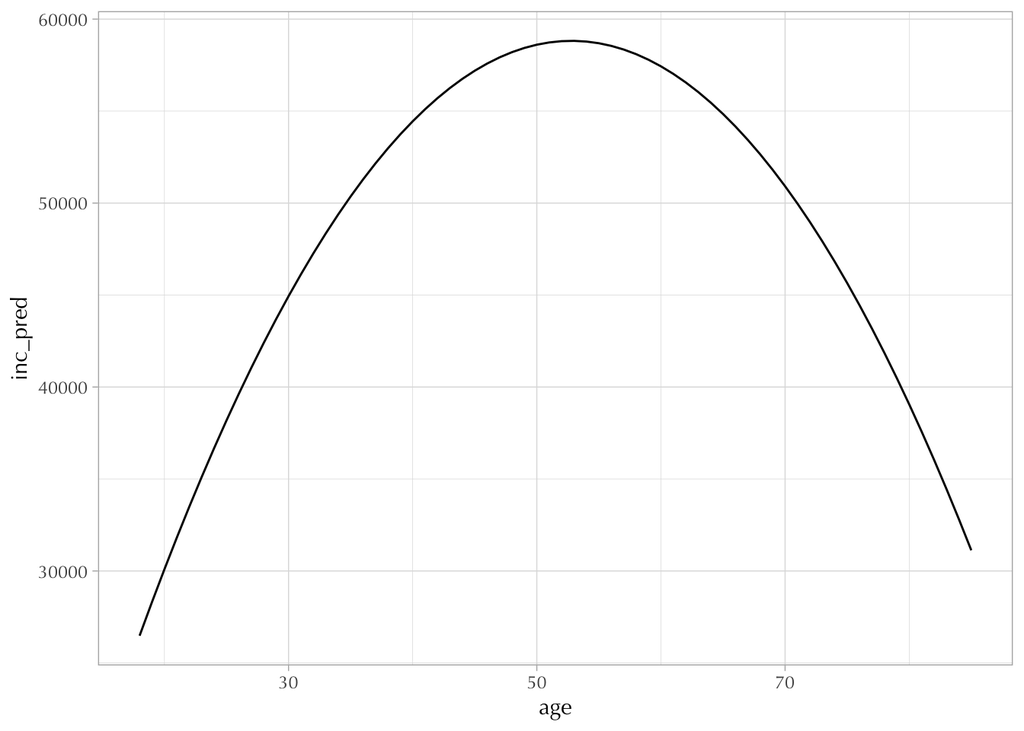

```r
pred_df <- data.frame(age = c(18:85)) |>
  mutate(age_sq = age^2)
pred_df$inc_pred <- predict(mod3, pred_df)
ggplot(pred_df, aes(x = age, y = inc_pred)) +
  geom_line()
```

# 12.1.9 Transformation

```r
df <- df |>
  mutate(
    age_centered = age - mean(age, na.rm = TRUE),
    age_centered_sq = age_centered^2
    )

mod4 <- lm(formula = coninc ~ age_centered + age_centered_sq, data = df)
summary(mod4)
```

```
Call:
lm(formula = coninc ~ age_centered + age_centered_sq, data = df)

Residuals:
   Min     1Q Median     3Q    Max
-58467 -29026 -10827  16788 131721

Coefficients:
                 Estimate Std. Error t value Pr(>|t|)
(Intercept)     58400.986   1250.083  46.718  < 2e-16 ***
age_centered      211.214     51.871   4.072 4.83e-05 ***
age_centered_sq   -26.706      2.765  -9.659  < 2e-16 ***
---
Signif. codes:  0 '***' 0.001 '**' 0.01 '*' 0.05 '.' 0.1 ' ' 1

Residual standard error: 41520 on 2144 degrees of freedom
Multiple R-squared:  0.04324,   Adjusted R-squared:  0.04235
F-statistic: 48.45 on 2 and 2144 DF,  p-value: < 2.2e-16
```

The coefficient $\beta_0$ (intercept) and $\beta_1$ (the coefficient before `age`) have both changed, but $\beta_2$ (the coefficient before the squared term) does not change. Besides, the standard error of the coefficient before the squared term also remains the same, thus t-value of that coefficient is also the same.

$\beta_0$ here is the average income of people at the mean age.

# 12.1.10 Standardize

```r
df <- df |>
  mutate(
    age_standard = (age - mean(age, na.rm = TRUE))/sd(age, na.rm = TRUE),
    age_standard_sq = age_standard^2
    )

mod5 <- lm(formula = coninc ~ age_standard + age_standard_sq, data = df)
summary(mod5)
```

```
Call:
lm(formula = coninc ~ age_standard + age_standard_sq, data = df)

Residuals:
   Min     1Q Median     3Q    Max
-58467 -29026 -10827  16788 131721

Coefficients:
                Estimate Std. Error t value Pr(>|t|)
(Intercept)      58401.0     1250.1  46.718  < 2e-16 ***
age_standard      3751.0      921.2   4.072 4.83e-05 ***
age_standard_sq  -8422.7      872.0  -9.659  < 2e-16 ***
---
Signif. codes:  0 '***' 0.001 '**' 0.01 '*' 0.05 '.' 0.1 ' ' 1

Residual standard error: 41520 on 2144 degrees of freedom
Multiple R-squared:  0.04324,   Adjusted R-squared:  0.04235
F-statistic: 48.45 on 2 and 2144 DF,  p-value: < 2.2e-16
```

Compared to the centered model, the intercept $\beta_0$ remains the same, while $\beta_1$ and $\beta_2$ changed. However, we can see that the t-values all remain the same.

$\beta_0$ here is still the average income of people at the mean age.

Instead of interpreting $\beta_1$ and $\beta_2$ separately by their effect size, it would make more sense to interpret them together by the shape of curve it would show. I did the prediction plot here:

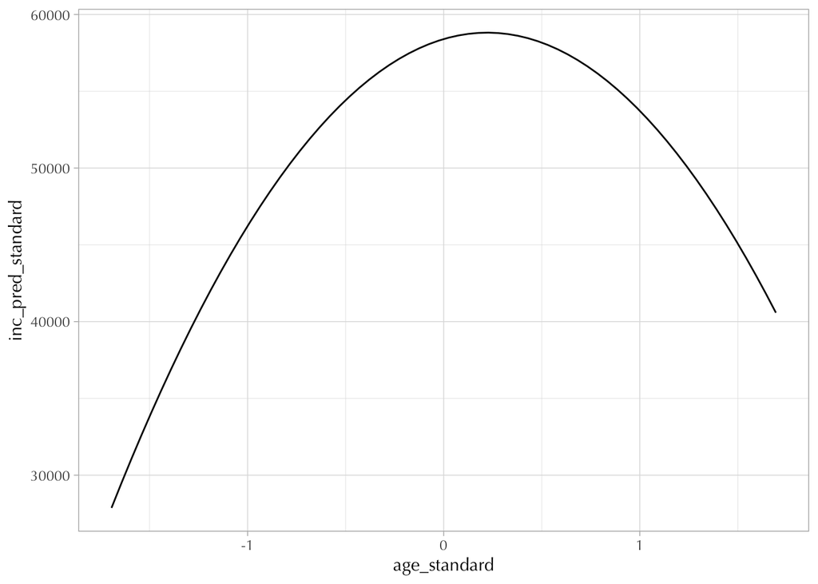

```r
pred_df <- pred_df |>
  mutate(
    age_standard = (age - mean(age, na.rm = TRUE))/sd(age, na.rm = TRUE),
    age_standard_sq = age_standard^2
  )

pred_df$inc_pred_standard <- predict(mod5, pred_df)
ggplot(pred_df, aes(x = age_standard, y = inc_pred_standard)) +
  geom_line()
```

This actually can show the relationship between standardized age and income: Before the peak point (which was a little more than the mean age), the income will increase as age grows. However, after the peak point, income will decrease as age grows. The turning point equals to $-\frac{\beta_1}{2\beta_2}$

# 12.1.11 Inc ~ Married

$$coninc=\beta_0+\beta_1married$$

```r
df <- gss18 |>
  select(marital, coninc, sex) |>
  mutate(
    coninc = haven::zap_label(coninc),
    sex = haven::as_factor(sex),
    marital = haven::as_factor(marital)
  ) |>
  drop_na() |>
  mutate(
    married_new = if_else(marital == "married", T, F),
    male = factor(ifelse(sex == "male", T, F))
    )

df |>
  group_by(married_new) |>
  summarize(
    avg_coninc = mean(coninc, na.rm = TRUE),
    sd = sd(coninc, na.rm = TRUE),
    n = n()
  ) |>
  mutate(std_error = sd / n())
```

```
# A tibble: 2 × 5
  married_new avg_coninc     sd     n std_error
  <lgl>            <dbl>  <dbl> <int>     <dbl>
1 FALSE           36818. 34643.  1229    17321.
2 TRUE            67492. 45378.   923    22689.
```

```r
mod6 <- lm(formula = coninc ~ married_new, data = df)
summary(mod6)
```

```
Call:
lm(formula = coninc ~ married_new, data = df)

Residuals:
   Min     1Q Median     3Q    Max
-67141 -27179  -9659  16628 121384

Coefficients:
                Estimate Std. Error t value Pr(>|t|)
(Intercept)        36818       1130   32.59   <2e-16 ***
married_newTRUE    30674       1725   17.78   <2e-16 ***
---
Signif. codes:  0 '***' 0.001 '**' 0.01 '*' 0.05 '.' 0.1 ' ' 1

Residual standard error: 39600 on 2150 degrees of freedom
Multiple R-squared:  0.1282,    Adjusted R-squared:  0.1278
F-statistic: 316.2 on 1 and 2150 DF,  p-value: < 2.2e-16
```

Compared with the `dplyr` table, I can find:

- The value of intercept $\beta_0$ is equal to the average income of unmarried people (`married = 0`). The value of $\beta_1$ is equal to the average income of married people less the average income of unmarried 67492-36818 = 30674.
- The standard error of the coefficient:

$$\begin{align}
se(\bar{x_1}-\bar{x_2})&=\sqrt{\frac{\sigma_1^2}{n_1}+\frac{\sigma_2^2}{n_2}}\\
&=\sqrt{\frac{34643^2}{1229}+\frac{45378^2}{923}}\\
&=1791
\end{align}$$

Which is very close to the standard error 1725 presented in the regression table.

# 12.1.12 Interactions

```r
df |>
  group_by(male, married_new) |>
  summarize(coninc = mean(coninc, na.rm = TRUE))
```

```
# A tibble: 4 × 3
# Groups:   male [2]
  male  married_new coninc
  <fct> <lgl>        <dbl>
1 FALSE FALSE       33561.
2 FALSE TRUE        66760.
3 TRUE  FALSE       41015.
4 TRUE  TRUE        68292.
```

$$coninc = \beta_0+\beta_1male_i+\beta_2married_i+\beta_3male_i\times married_i$$

| male | married | `coninc` | regression output |
| --- | --- | --- | --- |
| 0 | 0 | 33560.78 | $\beta_0$ |
| 0 | 1 | 66759.76 | $\beta_0+\beta_2$ |
| 1 | 0 | 41014.66 | $\beta_0+\beta_1$ |
| 1 | 1 | 68292.14 | $\beta_0+\beta_1+\beta_2+\beta_3$ |

# 12.1.13 Bike ride

```r
data(bikes, package = "bayesrules")
str(bikes)
```

```
'data.frame':   500 obs. of  13 variables:
 $ date       : Date, format: "2011-01-01" "2011-01-03" ...
 $ season     : Factor w/ 4 levels "fall","spring",..: 4 4 4 4 4 4 4 4 4 4 ...
 $ year       : int  2011 2011 2011 2011 2011 2011 2011 2011 2011 2011 ...
 $ month      : Factor w/ 12 levels "Apr","Aug","Dec",..: 5 5 5 5 5 5 5 5 5 5 ...
 $ day_of_week: Factor w/ 7 levels "Fri","Mon","Sat",..: 3 2 6 7 1 3 2 6 7 5 ...
 $ weekend    : logi  TRUE FALSE FALSE FALSE FALSE TRUE ...
 $ holiday    : Factor w/ 2 levels "no","yes": 1 1 1 1 1 1 1 1 1 1 ...
 $ temp_actual: num  57.4 46.5 46.8 48.7 46.5 ...
 $ temp_feel  : num  64.7 49 51.1 52.6 50.8 ...
 $ humidity   : num  80.6 43.7 59 43.7 49.9 ...
 $ windspeed  : num  10.7 16.6 10.7 12.5 11.3 ...
 $ weather_cat: Factor w/ 3 levels "categ1","categ2",..: 2 1 1 1 2 2 1 2 1 1 ...
 $ rides      : int  654 1229 1454 1518 1362 891 1280 1220 1137 1368 ...
```

```r
df <- bikes |>
  mutate(
    windspeed_centered = windspeed - mean(windspeed, na.rm = T),
    temp_feel_centered = temp_feel - mean(temp_feel, na.rm = T)
  )

 mod7 <- lm(formula = rides ~ windspeed_centered + weekend + temp_feel_centered, data = df)
 summary(mod7)
```

```
Call:
lm(formula = rides ~ windspeed_centered + weekend + temp_feel_centered,
    data = df)

Residuals:
    Min      1Q  Median      3Q     Max
-3490.3  -948.8  -107.0   936.4  3258.0

Coefficients:
                   Estimate Std. Error t value Pr(>|t|)
(Intercept)        3683.442     64.967  56.697  < 2e-16 ***
windspeed_centered  -32.821     10.072  -3.259   0.0012 **
weekendTRUE        -713.575    122.478  -5.826 1.02e-08 ***
temp_feel_centered   77.966      4.978  15.662  < 2e-16 ***
---
Signif. codes:  0 '***' 0.001 '**' 0.01 '*' 0.05 '.' 0.1 ' ' 1

Residual standard error: 1230 on 496 degrees of freedom
Multiple R-squared:  0.3931,    Adjusted R-squared:  0.3895
F-statistic: 107.1 on 3 and 496 DF,  p-value: < 2.2e-16
```

If the temperature and wind speed are at their average level, the expected ridership for a weekend day would be 3683.44 - 713.58=2969.86. The expected ridership for a weekday would be 3683.44.

# 12.1.14 Poisson model

```r
mod8 <- glm(formula = rides ~ windspeed_centered + weekend + temp_feel_centered, data = df, family = poisson (link = "log"))

exp(tidy(mod8)[1,2])
```

```
# A tibble: 1 × 1
  estimate
     <dbl>
1    3549.
```

```r
exp(tidy(mod8)[1,2]+tidy(mod8)[3,2])
```

```
  estimate
1 2857.843
```

Based on the poisson model, if the temperature and the wind speed are average, the expected ridership for a weekend day would be 2857.84, while the expected ridership for a week day would be 3549. The result is close to the normal linear model, but still have some gap.

# 12.1.15 Model fit

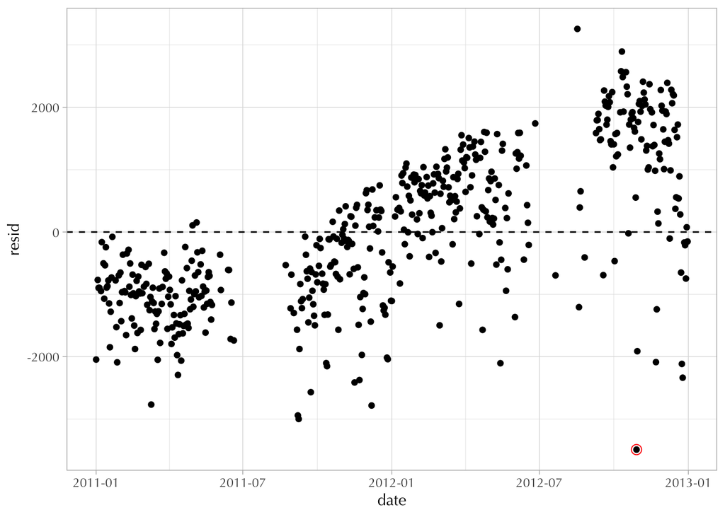

```r
mod_normal <- glm(rides ~ windspeed + temp_feel + weekend, data = bikes, family = "gaussian")
bikes$resid <- residuals(mod_normal)

bikes |>
  ggplot(aes(date, resid)) +
  geom_point() +
  geom_hline(yintercept = 0, linetype = "dashed") +
  geom_point(
    data = filter(bikes, abs(resid) == max(abs(resid))),
    color = "red", shape = 21, size = 3
  )
```

```r
data
```

[output not shown]

[output cut: 134 more lines]

[output not shown]

The plot shows that the residuals are not symmetrically distributed around 0, i.e. it does not satisfy normality. It seems that there is an increasing trend for residuals along the date axis.

The outlier residual was on 2012-10-29, when there was Hurricane Sandy. That is why the bikeshare ridership is over-estimated so much by the model.